# Simple Linear Regression

2025

## Simple Linear Regression

- We have seen that **correlation** measures the **strength and direction** of a linear relationship between two variables.
- **Simple linear regression** goes one step further: It models the relationship between two variables so we can **predict** the outcome variable \(Y\) from the predictor variable \(X\).
- It states how much \(Y\) changes when \(X\) changes by a given amount.

## Visualising correlation and regression

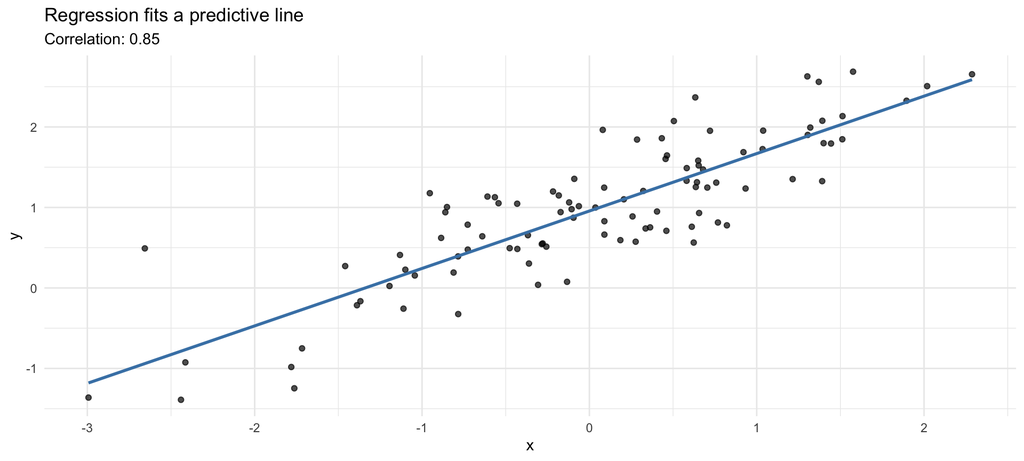

## Regression model

- For the \(i^\text{th}\) observation, we can write:

\[ y_{i} = \beta_{0} + \beta_{1} x_{i} + \epsilon_{i} \]

- \(y_{i}\) is the \(i^\text{th}\) observed outcome.
- \(x_{i}\) is the \(i^\text{th}\) value of the predictor variable.
- \(\epsilon_{i}\) is called the **residual** and is the difference between the observed outcome and the predicted outcome.

\[ \epsilon_{i} \sim \mathscr{N}(0, \sigma_{\epsilon}) \]

- \(\beta_{0}\) and \(\beta_{1}\) are population parameters of the linear regression model.

## Regression model

- Now lets extend to many observations:

\[ \begin{align} y_{1} &= \beta_{0} + \beta_{1} x_{1} + \epsilon_{1} \\ y_{2} &= \beta_{0} + \beta_{1} x_{2} + \epsilon_{2} \\ &\vdots \\ y_{n} &= \beta_{0} + \beta_{1} x_{n} + \epsilon_{n} \\ \end{align} \]

## Regression model

- We can gather the independent observations up into vectors:

\[ \begin{align} \begin{bmatrix} y_1\\ y_2\\ \vdots\\ y_n \end{bmatrix} &= \beta_{0} \begin{bmatrix} 1\\ 1\\ \vdots\\ 1 \end{bmatrix} + \beta_{1} \begin{bmatrix} x_1\\ x_2\\ \vdots\\ x_n\\ \end{bmatrix} + \begin{bmatrix} \epsilon_1\\ \epsilon_2\\ \vdots\\ \epsilon_n\\ \end{bmatrix} \\\\ \end{align} \]

## Regression model

- We can next gather the vectors up into a matrix:

\[ \begin{align} \begin{bmatrix} y_1\\ y_2\\ \vdots\\ y_n \end{bmatrix} &= \begin{bmatrix} 1 & x_1 \\ 1 & x_2 \\ \vdots & \vdots \\ 1 & x_n \end{bmatrix} \begin{bmatrix} \beta_{0} \\ \beta_{1} \end{bmatrix} + \begin{bmatrix} \epsilon_1\\ \epsilon_2\\ \vdots\\ \epsilon_n\\ \end{bmatrix} \\\\ \end{align} \]

## Regression model

- We can finally write the model in compact matrix form:

\[ \begin{align} \boldsymbol{y} &= \boldsymbol{X} \boldsymbol{\beta} + \boldsymbol{\epsilon} \end{align} \]

- \(\boldsymbol{y}\) is a vector of observed outcomes.
- \(\boldsymbol{X}\) is a matrix of predictor variables and is called the **design matrix**
- \(\boldsymbol{\beta}\) is a vector of \(\beta\) parameters.
- \(\boldsymbol{\epsilon}\) is a vector of residuals.

## How can we pick \(\boldsymbol{\beta}\) values that best fit our data?

- let \(y_i\) denote observed values
- let \(\widehat{y_{i}}\) denote predicted values:

\[ \widehat{y_{i}} = \beta_{0} + \beta_{1} x_{i} \]

- The best fitting \(\boldsymbol{\beta}\) values are those that minimise the discrepancy between \(y_{i}\) and \(\widehat{y_{i}}\).

\[ \DeclareMathOperator*{\argmin}{\arg\!\min} \argmin_{\boldsymbol{\beta}} \sum_{i=1}^{n} (y_{i} - \widehat{y_{i}})^2 \]

\[ \DeclareMathOperator*{\argmin}{\arg\!\min} \argmin_{\boldsymbol{\beta}} \sum_{i=1}^{n} (y_{i} - (\beta_{0} + \beta_{1} x_{i}))^2 \]

- The \(\boldsymbol{\beta}\) values that minimise error can be solved for analytically.
- The method is to take the derivative with respect to \(\boldsymbol{\beta}\), and then find the \(\boldsymbol{\beta}\) values that make the resulting expression equal to zero.
- I won’t do this here and won’t require you to do so either.
- You should know however that this method of finding \(\beta\) values is called **ordinary least squares**.

## Example regression \(\widehat{\beta}\) estimates

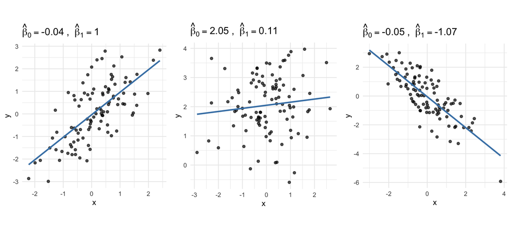

## Testing \(\beta\) values for significance

- We can use the best fitting \(\widehat{\beta}\) values to ansswer questions about the population \(\beta\) parameters (e.g., is either significantly different from zero?).
- The raw data in a regression analysis are random samples \(\boldsymbol{x}\) and \(\boldsymbol{y}\) from random variables \(X\) and \(Y\).
- Therefore the \(\widehat{\beta}\) values are also random variables.
- It turns out the best fitting \(\beta\) values (i.e., \(\hat{\beta}\)) can be tested with a \(t\)-test.

## 1. NHST for \(\beta\) values

- We test each regression coefficient \(\beta_0\) and \(\beta_1\) to see if it is significantly different from 0.

\[ \begin{align} H_0: & \ \beta_0 = 0 \\ H_1: & \ \beta_0 \neq 0 \end{align} \]

\[ \begin{align} H_0: & \ \beta_1 = 0 \\ H_1: & \ \beta_1 \neq 0 \end{align} \]

- We are usually most interested in \(\beta_1\) because it tells us how much \(Y\) changes when \(X\) changes by a given amount, so we focus on that moving forward.

## 2. Choose a significance level

- We pick a Type I error rate:

\[ \alpha = 0.05 \]

## 3. Sampling distribution of \(\widehat{\beta}\)

- We obtain \(\widehat{\beta}_1\) using **ordinary least squares (OLS)** and describe its sampling distribution:

\[ \begin{align} \widehat{\beta}_1 &\sim \mathscr{N}(\beta_1, \sigma_{\widehat{\beta}_1}) \\ \widehat{\beta}_1 &\sim \mathscr{N}(0, \sigma_{\widehat{\beta}_1}) \quad \text{if } H_0 \text{ is true} \end{align} \]

- To test the null hypothesis, we compute a \(t\)-statistic:

\[ t = \frac{\widehat{\beta}_1 - 0}{\sigma_{\widehat{\beta}_1}} \sim t(n - 2) \]

## Regression model terms

- \(SS_{error} = SS_{residual} = \sum_{i=1}^{n} (y_{i} - \hat{y_{i}})^2\)
- \(SS_{error}\) is what you get when you compare raw observations against the full model predictions.
- \(SS_{total} = \sum_{i=1}^{n} (y_{i} - \bar{y_{i}})^2\)
- \(SS_{total}\) is what you get when you compare raw observations against the grand mean.
- \(SS_{error}\) comes from \(\sum_{i=1}^{n} (y_{i} - \hat{y_{i}})^2\) with \(\hat{y} = \beta_{0} + \beta_{1} x + \epsilon\),
- \(SS_{total}\) comes from \(\sum_{i=1}^{n} (y_{i} - \hat{y_{i}})^2\) with \(\hat{y} = \bar{y} + \epsilon\)
- \(SS_{model} = \sum_{i=1}^{n} (\bar{y} - \hat{y_i})^2\) tells you how much the added complexity of the full model reduces the overall variability (i.e., makes better predictions).
- The percent of variability accounted for above the simple model is given by:

\[R^2 = \frac{SS_{model}}{SS_{total}}\]

- \(R^2\) is called the **coefficient of determination** and is just the sqaure of the correlation coefficient between \(x\) and \(y\).
- The \(F\) ratio tells us whether or not the more complex model provides a significantly better fit to the data than the simplest model

\[ F = \frac{MS_{model}}{MS_{error}} \]

- The regression \(F\)-ratio tells us how much the regression model has improved the prediction over the simple mean model relative to the overall inaccuracy in the regression model.

## Simple linear regression in `R`

- Suppose we obtain data on two variables \(X\) and \(Y\).

```
##                 x          y
##             <num>      <num>
##   1: -0.341066980  1.4756824
##   2:  1.502424534  3.7369983
##   3:  0.528307712  2.2191545
##   4:  0.542191355  2.2640871
##   5: -0.136673356  1.3699349
##   6: -1.136733853  0.7595680
##   7: -1.496627154  0.4901085
##   8: -0.223385644  1.6773231
##   9:  2.001719228  3.6813218
##  10:  0.221703816  2.9877493
##  11:  0.164372909  2.8663688
##  12:  0.332623609  2.8146896
##  13: -0.385207999  1.6885979
```

[output cut: 88 more lines]

- We can plot the data to see if there is a relationship between \(x\) and \(y\).

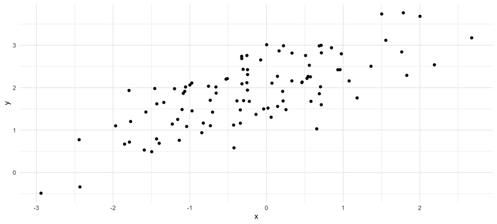

- We can fit a simple linear regression model in `R` using the `lm` function.

```r
fm <- lm(y ~ x, data=d)
```

```r
summary(fm)
```

```
##
## Call:
## lm(formula = y ~ x, data = d)
##
## Residuals:
##      Min       1Q   Median       3Q      Max
## -1.34112 -0.44276 -0.03841  0.46488  1.00040
##
## Coefficients:
##             Estimate Std. Error t value Pr(>|t|)
## (Intercept)  2.01015    0.05581   36.02   <2e-16 ***
## x            0.55023    0.05103   10.78   <2e-16 ***
## ---
## Signif. codes:  0 '***' 0.001 '**' 0.01 '*' 0.05 '.' 0.1 ' ' 1
##
## Residual standard error: 0.5487 on 98 degrees of freedom
## Multiple R-squared:  0.5427, Adjusted R-squared:  0.538
## F-statistic: 116.3 on 1 and 98 DF,  p-value: < 2.2e-16
```

- The `Estimate` column provides the best fitting \(\beta\) values.
- The `Std. Error` column provides the SEM associated with the \(\beta\) values reported in the `Estimate` column.
- The `t value` column provides the \(t\)-statistic for the null hypothesis that the \(\beta\) value is zero.
- The `Pr(>|t|)` column provides the \(p\)-value associated with the \(t\)-statistic.
- The `Residual standard error` provides an estimate of the standard deviation of the residuals.
- The `Multiple R-squared` provides the \(R^2\) value.
- The `Adjusted R-squared` provides the \(R^2\) value adjusted for the number of predictors in the model.
- The `F-statistic` provides the \(F\)-ratio and the `p-value` reported next to it provides the \(p\)-value associated with the \(F\)-ratio.
- The best-fitting \(\beta_0\) is 2.01 and the best fitting \(\beta_1\) is 0.55.
- \(\beta_0\) is the intercept and \(\beta_1\) is the slope of the regression model.

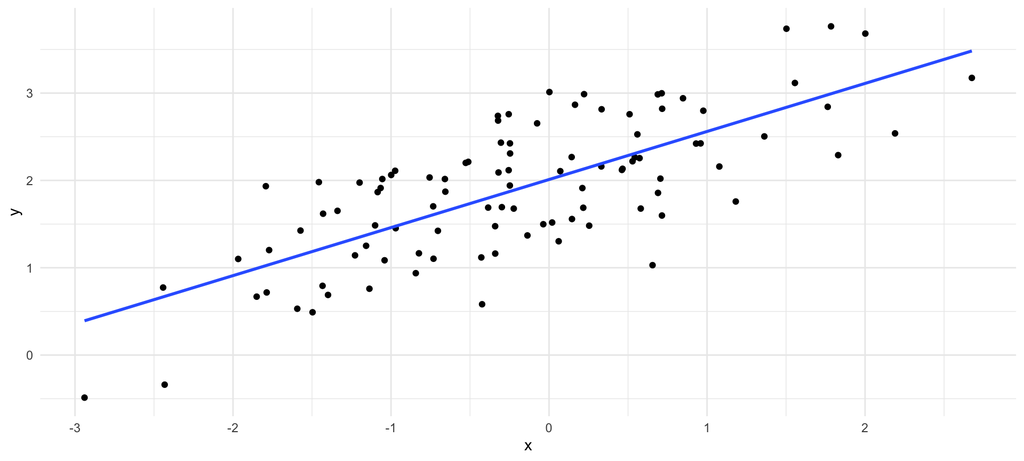

## Assumptions of simple linear regression

- The relationship between \(x\) and \(y\) is linear.
- The residuals are independent.
- The residuals are normally distributed.
- The residuals are homoscedastic.

## Check assumptions with plots

- A common diagnostic tool is to plot the residuals against the predicted values.
- If linearity holds then this plot will hover around zero from the beginning to the end of the observed range. The residuals should not show trends or patterns across the range of predicted values.
- If homoscedasticity holds then this plot will show a constant spread of residuals across the range of predicted values.
- If normality holds then the residuals will be normally distributed and we can use a histrogram of density plot to check as usual.

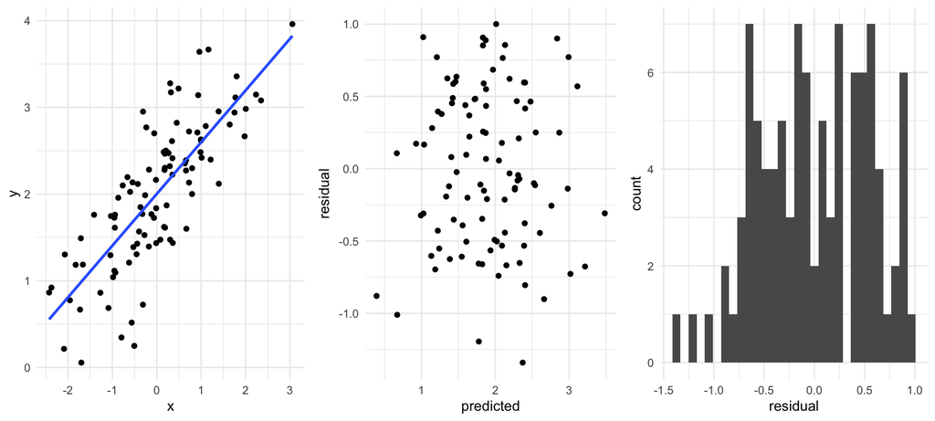

## More regression diagnostics

- We are just scratching the surface of regression, but we will not go much further in this course.
- If you’d like a taste, try `plot(fm)` to see a range of diagnostic plots. You can ask your favourite AI to explain them to you.

## Regression vs correlation

- Both are used to examine the relationship between variables.
- The sign of the regression coefficient (positive or negative) in simple linear regression involving one independent variable will always match the sign of the correlation coefficient between those two variables.
- In simple linear regression with one predictor, the square of the correlation coefficient \(r^2\) is equal to the coefficient of determination in regression analysis.
- Correlation provides a single metric describing the linear relationship between two variables.
- Regression is used to model the relationship and predict values, offering more detailed insight into how the variables interact.
- In simple linear regression, \(R^2\) (which is a measure of how well the variation in the dependent variable is explained by the independent variables) is exactly the square of the correlation coefficient \(r\)).

\[ R^2 = \frac{SS_{model}}{SS_{total}} = r^2 \]